# Отчёт по лабораторной работе №9

Операционные системы

Румянцев А.О

Российский университет дружбы народов, Москва, Россия

06 Апреля 2024

# Цель работы

Освоение основных возможностей командной оболочки Midnight Commander. Приобретение навыков практической работы по просмотру каталогов и файлов; манипуляций с ними.

# Задание

1. Создайте текстовой файл text.txt.
2. Откройте этот файл с помощью встроенного в mc редактора.
3. Вставьте в открытый файл небольшой фрагмент текста, скопированный из любого другого файла или Интернета.
4. Проделайте с текстом следующие манипуляции, используя горячие клавиши:
   - Удалите строку текста.
   - Выделите фрагмент текста и скопируйте его на новую строку.
   - Сохраните файл.
   - Отмените последнее действие.
   - Перейдите в конец файла (нажав комбинацию клавиш) и напишите некоторый текст.
   - Перейдите в начало файла (нажав комбинацию клавиш) и напишите некоторый текст.
   - Сохраните и закройте файл.
5. Откройте файл с исходным текстом на некотором языке программирования (напри- мер C или Java)
6. Используя меню редактора, включите подсветку синтаксиса, если она не включена, или выключите, если она включена

# Теоретическое введение

Командная оболочка — интерфейс взаимодействия пользователя с операционной системой и программным обеспечением посредством команд. Midnight Commander (или mc) — псевдографическая командная оболочка для UNIX/Linux систем. Для запуска mc необходимо в командной строке набрать mc и нажать Enter .

MC имеет много полезных как для пользователей, так и для администраторов, функций (копирование, удаление, переименование/перемещение, создание директорий).

Главное окно программы Midnight Commander состоит из трех полей. Два поля, называемые “панелями”, идентичны по структуре и обычно отображают перечни файлов и подкаталогов каких-то двух каталогов файловой структуры. Эти каталоги в общем случае различны, хотя, в частности, могут и совпасть. Каждая панель состоит из заголовка, списка файлов и информационной строки.

Третье поле экрана, расположенное в нижней части экрана, содержит командную строку текущей оболочки. В этом же поле (самая нижняя строка экрана) содержится подсказка по использованию функциональных клавиш F1 - F10. Самая верхняя строка экрана содержит строку горизонтального меню. Эта строка может не отображаться на экране; в этом случае доступ к ней можно получить, щёлкнув мышью по верхней рамке или нажав клавишу F9.

# Выполнение лабораторной работы

## С помощью команды man mc прочитал документацию про командную оболочку

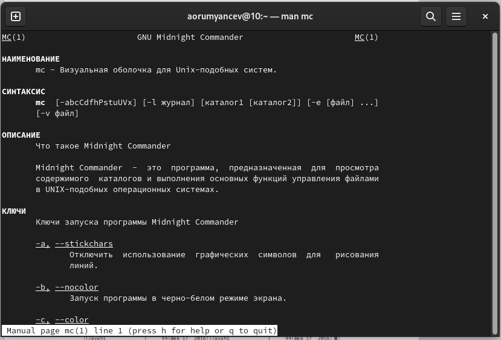

## Ввожу в терминале mc и получаю окно, в котором далее смогу работать.

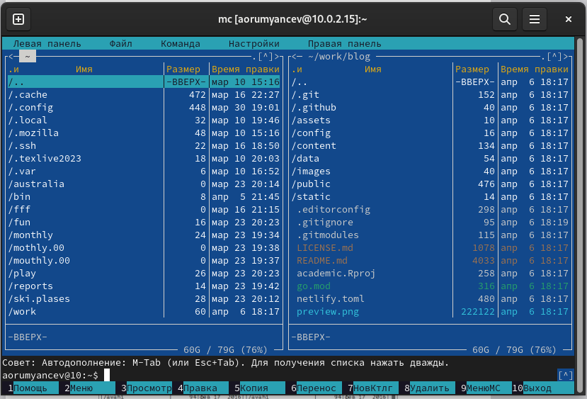

## С помощью стрелочек влево вправо я могу перемещаться по директориям, а с помощью стрелочек вверх вниз перебирать файлы в директории, в которой нахожусь.

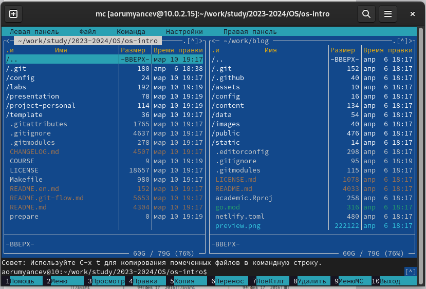

## С помощью F5 могу создать копию файла в выбранном каталоге.

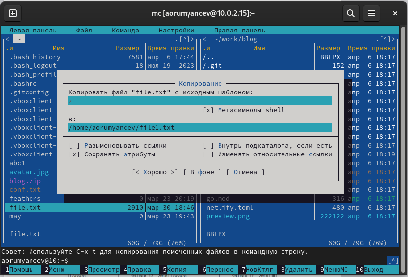

## С помощью управляющих клавиш так же можно получить информацию о правах доступа на файл и информацию о нем.

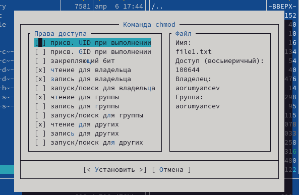

## В меню правой панели вывел информацию о файле, получаю информации больше чем в выводе ls-l

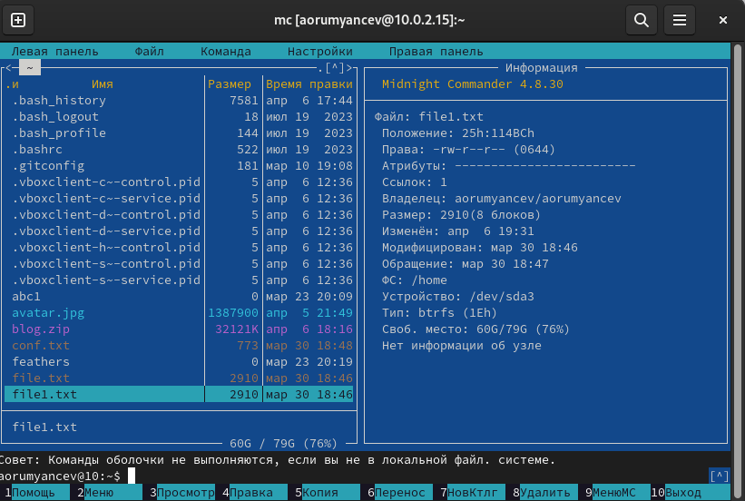

## Используя возможности подменю “Файл” я посмотрел содержимое текстового файла

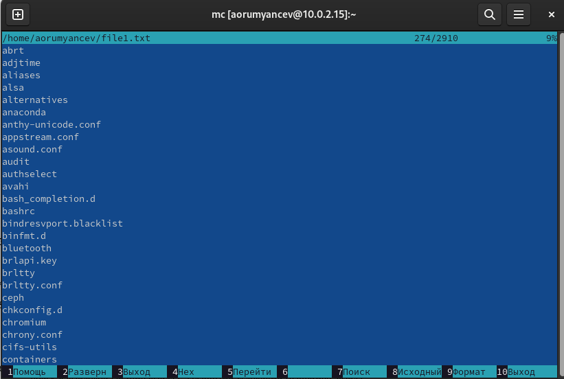

## Открыл файл на изменение, поменял пару строк и закрыл без сохранения.

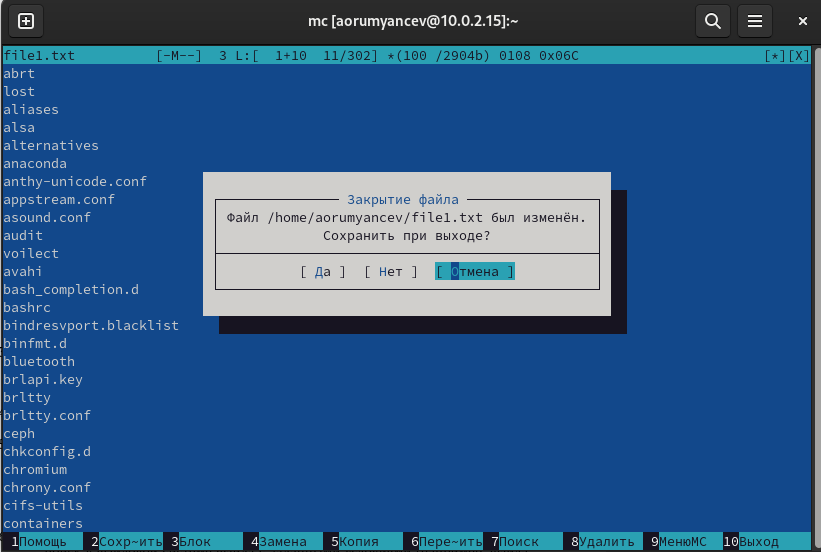

## Создал новый каталог.

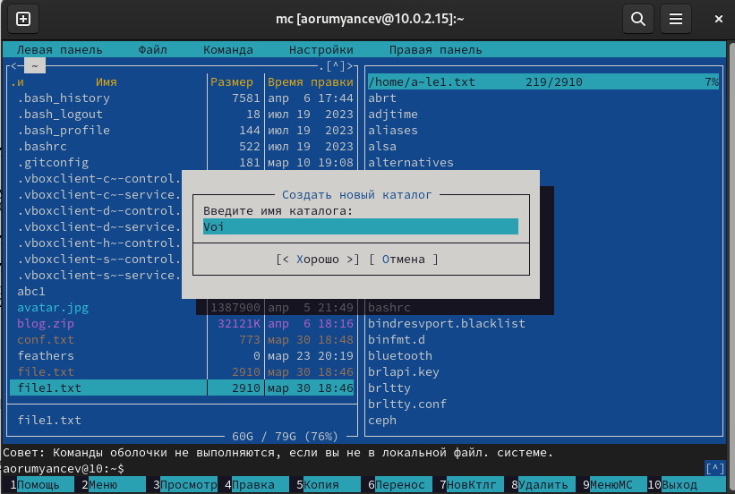

## Копирую файл в созданный каталог.

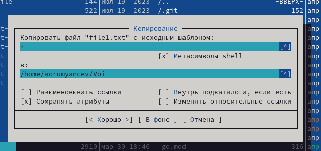

## С помощью средств подменю **“Команда”** можно найти файл с заданным условием, я искал файлы формата .txt

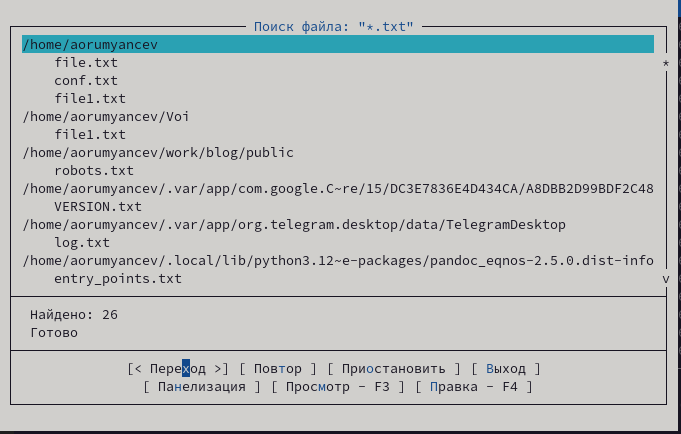

## Можно перемещаться между директориями, я перемещусь в домашнюю.

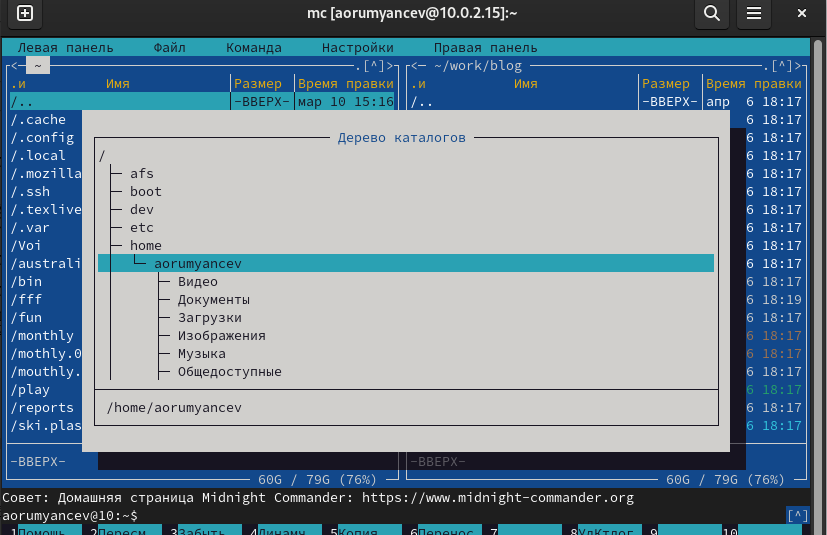

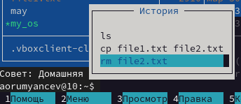

## Анализирую файл расширения.

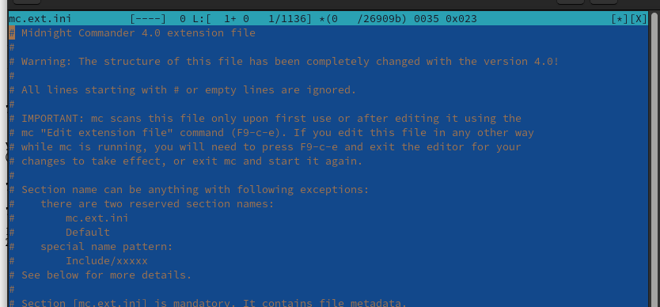

## Анализирую файл меню

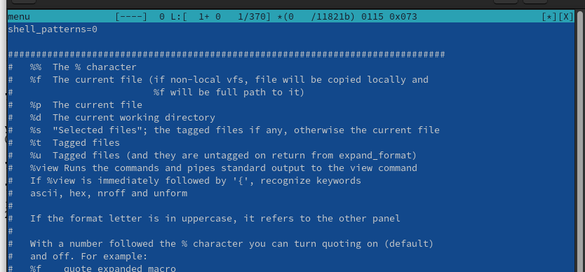

## Из подменю настройки вызвал окна настройки панели

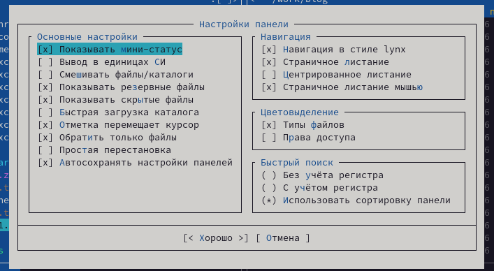

## Вызвал настройки внешнего вида

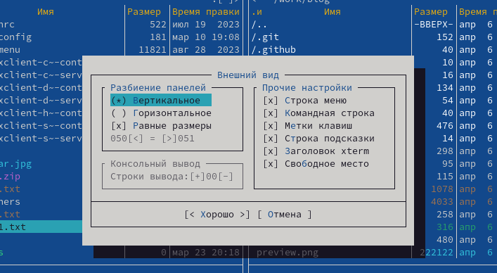

## Вызвал настройки распознавания клавиш

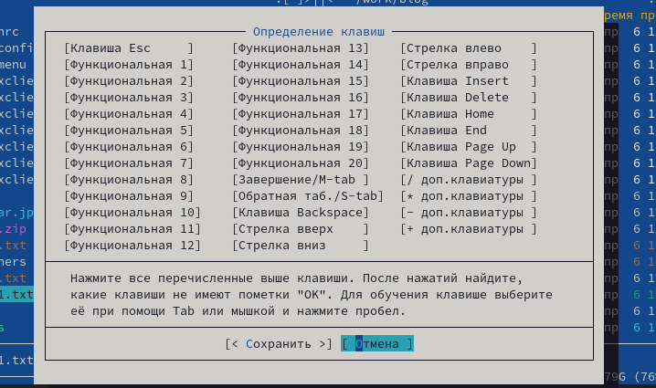

## Вызвал параметры конфигурации

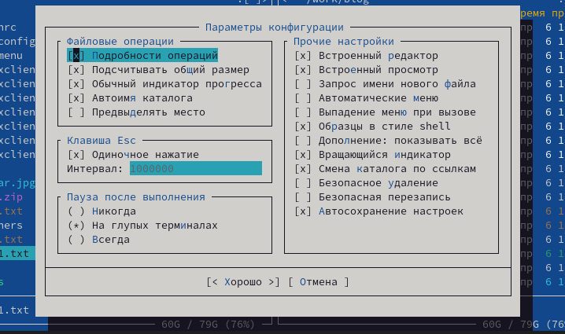

## Командой touch text.txt создал файл

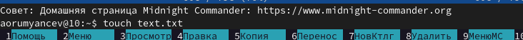

## Клавишей F4 открыл файл для записи, добавил в него текст.

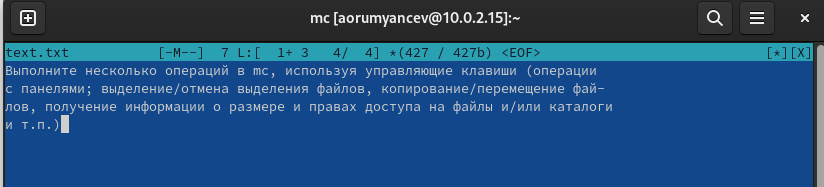

## Выделяю текст с помощью клавиши F3 и кликов мышью

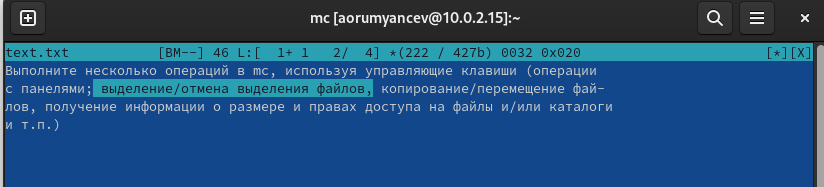

## Перемещаю выделенный текст с помощью клавиши F6

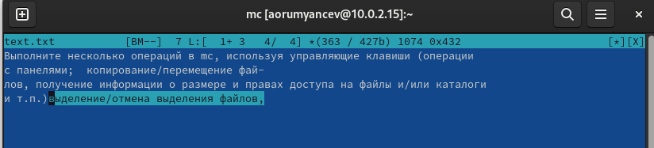

## Удалил строку текста с помощью ctrl+y

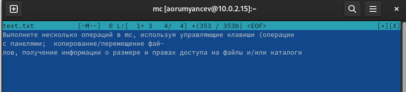

## Сохраняю изменения в файле с помощью горячей клавиши F2

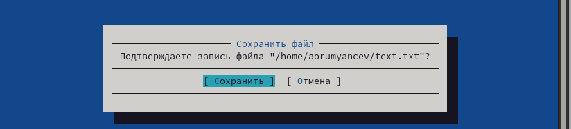

## С помощью ctrl+u отменяю последнее действие и возвращаю удаленную строку

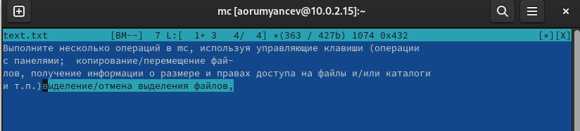

## С помощью клавиш pgup pgdn у меня получилось попасть в начало и в конец файла соответственно, я добавил текст в начало и в конец файла

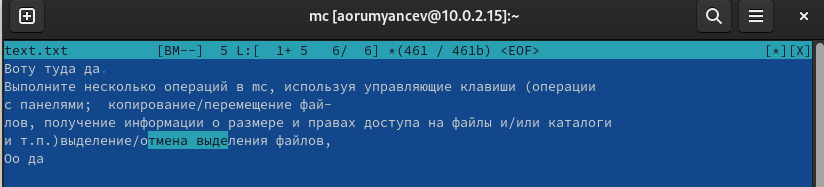

## Горячая клавиша F10 закрывает файл, дополнительно справшивая сохранить ли в нем не сохраненные изменения, сохраняю и закрываю

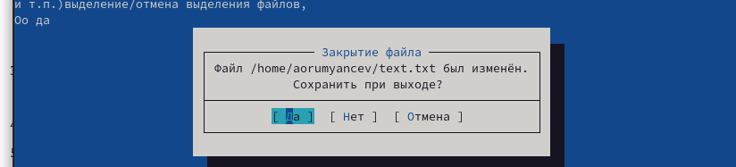

## Открываю файл формата .cpp, с кодом на С++, встроенный редактор mc вывел его содержимое с подстветкой.

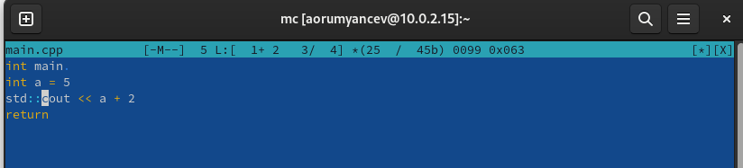

## Я отключил подсветку и вывел снова тот же самый файл, но уже без подсветки.

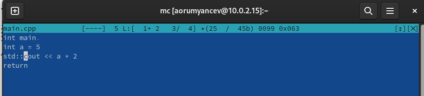

# Выводы

При выполнении данной лабораторной работы, я освоил основные возможности командной оболочки Midnight Commander, приобрел навыки практической работы по просмотру каталогов и файлов; манипуляций с ними.

# Ответы на контрольные вопросы

3. Опишите структура меню левой (или правой) панели mc, дайте характеристику командам.

В меню каждой (левой или правой) панели можно выбрать Формат списка: - стандартный — выводит список файлов и каталогов с указанием размера и времени правки; - ускоренный — позволяет задать число столбцов, на которые разбивается панель при выводе списка имён файлов или каталогов без дополнительной информации; - расширенный — помимо названия файла или каталога выводит сведения о правах доступа, владельце, группе, размере, времени правки; - определённый пользователем — позволяет вывести те сведения о файле или каталоге, которые задаст сам пользователь.

4. Опишите структура меню Файл mc, дайте характеристику командам. В меню Файл содержит перечень команд, которые могут быть применены к одному или нескольким файлам или каталогам.

Команды меню Файл: - Просмотр ( F3 ) — позволяет посмотреть содержимое текущего (или выделенного) файла без возможности редактирования. - Просмотр вывода команды ( М + ! ) — функция запроса команды с параметрами (аргумент к текущему выбранному файлу). - Правка ( F4 ) — открывает текущий (или выделенный) файл для его редактирования. - Копирование ( F5 ) — осуществляет копирование одного или нескольких файлов или каталогов в указанное пользователем во всплывающем окне место. - Права доступа ( Ctrl-x c ) — позволяет указать (изменить) права доступа к одному или нескольким файлам или каталогам . - Жёсткая ссылка ( Ctrl-x l ) — позволяет создать жёсткую ссылку к текущему (или выделенному) файлу. - Символическая ссылка ( Ctrl-x s ) — позволяет создать символическую ссылку к текущему (или выделенному) файлу. - Владелец/группа ( Ctrl-x o ) — позволяет задать (изменить) владельца и имя группы для одного или нескольких файлов или каталогов. - Права (расширенные) — позволяет изменить права доступа и владения для одного или нескольких файлов или каталогов. - Переименование ( F6 ) — позволяет переименовать (или переместить) один или несколько файлов или каталогов. - Создание каталога ( F7 ) — позволяет создать каталог. - Удалить ( F8 ) — позволяет удалить один или несколько файлов или каталогов. - Выход ( F10 ) — завершает работу mc.

5. Опишите структура меню Команда mc, дайте характеристику командам.

В меню Команда содержатся более общие команды для работы с mc. Команды меню Команда:

- Дерево каталогов — отображает структуру каталогов системы.
- Поиск файла — выполняет поиск файлов по заданным параметрам.
- Переставить панели — меняет местами левую и правую панели.
- Сравнить каталоги ( Ctrl-x d ) — сравнивает содержимое двух каталогов.
- Размеры каталогов — отображает размер и время изменения каталога (по умолчанию в mc размер - каталога корректно не отображается).
- История командной строки — выводит на экран список ранее выполненных в оболочке команд.
- Каталоги быстрого доступа ( Ctrl- ) — пр вызове выполняется быстрая смена текущего каталога на один из заданного списка.
- Восстановление файлов — позволяет восстановить файлы на файловых системах ext2 и ext3.
- Редактировать файл расширений — позволяет задать с помощью определённого синтаксиса действия при запуске файлов с определённым расширением (например, какое программного обеспечение запускать для открытия или редактирования файлов с расширением doc или docx).
- Редактировать файл меню — позволяет отредактировать контекстное меню пользователя, вызываемое по клавише F2 .
- Редактировать файл расцветки имён — позволяет подобрать оптимальную для пользователя расцветку имён файлов в зависимости от их типа.
6. Опишите структура меню Настройки mc, дайте характеристику командам.

Меню Настройки содержит ряд дополнительных опций по внешнему виду и функциональности mc. Меню Настройки содержит: - Конфигурация — позволяет скорректировать настройки работы с панелями. - Внешний вид и Настройки панелей — определяет элементы (строка меню, командная строка, подсказки и прочее), отображаемые при вызове mc, а также геометрию расположения панелей и цветовыделение. - Биты символов — задаёт формат обработки информации локальным терминалом. - Подтверждение — позволяет установить или убрать вывод окна с запросом подтверждения действий при операциях удаления и перезаписи файлов, а также при выходе из программы. - Распознание клавиш — диалоговое окно используется для тестирования функциональных клавиш, клавиш управления курсором и прочее. - Виртуальные ФС –– настройки виртуальной файловой системы: тайм-аут, пароль и прочее.

7. Назовите и дайте характеристику встроенным командам mc.
   - F1 Вызов контекстно-зависимой подсказки;
   - F2 Вызов пользовательского меню с возможностью создания и/или дополнения дополнительных функций;
   - F3 Просмотр содержимого файла, на который указывает подсветка в активной панели (без возможности редактирования);
   - F4 Вызов встроенного в mc редактора для изменения содержания файла, на который указывает подсветка в активной панели;
   - F5 Копирование одного или нескольких файлов, отмеченных в первой (активной) панели, в каталог, отображаемый на второй панели;
   - F6 Перенос одного или нескольких файлов, отмеченных в первой (активной) панели, в каталог, отображаемый на второй панели;
   - F7 Создание подкаталога в каталоге, отображаемом в активной панели;
   - F8 Удаление одного или нескольких файлов (каталогов), отмеченных в первой (активной) панели файлов;
   - F9 Вызов меню mc;
   - F10 Выход из mc;
8. Назовите и дайте характеристику командам встроенного редактора mc.
   - Ctrl-y удалить строку;
   - Ctrl-u отмена последней операции; Ins вставка/замена;
   - F7 поиск (можно использовать регулярные выражения);
   - (стрелочка вверх)-F7 повтор последней операции поиска;
   - F4 замена;
   - F3 первое нажатие — начало выделения,
   - второе — окончание выделения;
   - F5 копировать выделенный фрагмент;
   - F6 переместить выделенный фрагмент;
   - F8 удалить выделенный фрагмент;
   - F2 записать изменения в файл;
   - F10 выйти из редактора.
9. Дайте характеристику средствам mc, которые позволяют создавать меню, определяемые пользователем.

Можете сохранить часто используемые команды панелизации под отдельными информативными именами, чтобы иметь возможность их быстро вызвать по этим именам. Для этого нужно набрать команду в строке ввода (строка “Команда”) и нажать кнопку Добавить. После этого потребуется ввести имя, по которому мы будем вызывать команду. В следующий раз вам достаточно будет выбрать нужное имя из списка, а не вводить всю команду заново.

10. Дайте характеристику средствам mc, которые позволяют выполнять действия, определяемые пользователем, над текущим файлом.

Панель в mc отображает список файлов текущего каталога. Абсолютный путь к этому каталогу отображается в заголовке панели. У активной панели заголовок и одна из её строк подсвечиваются. Управление панелями осуществляется с помощью определённых комбинаций клавиш или пунктов меню mc.